# 01a Contact reports

# Goal

Examine contact report data and assess suitability for text modeling. Specifically, 92,480 visit reports were pulled into an xml file on 2019-04-25.

# Libraries

```r
library(tidyverse)
library(xml2) # .xml file parsing
library(lubridate) # date formatting
library(tm) # topic modeling data cleanup
```

# Load data

Apparently the xml file contains lots of invalid entries, so reading it directly is a no-go:

```r
xml <- read_xml('data/2019-04-25 CAT contact reports.xml')
```

$\color{red}{\text{Error in doc_parse_file(con, encoding = encoding, as_html = as_html, options = options) :}}$ $\color{red}{\text{PCDATA invalid Char value 18 [9]}}$

But reading it in as a string works just fine.

```r
data <- read_file('data/2019-04-25 CAT contact reports.xml')
```

Now that that’s done, I can manually write each tag into a data frame.

```r
# Convert raw data into row data
rowdata <- data %>%
  str_replace_all(pattern = '( |  |\\r|\\n)', replacement = ' ') %>%
  str_extract_all(pattern = '<ROW>.*?</ROW>') %>%
  unlist()
```

```r
# Function to pull out specific elements between <TAG></TAG>
xmler <- function(data, tagname) {
  tag_pattern <- paste0('(?<=<', tagname, '>).*(?=</', tagname, '>)')
  return(
    str_extract_all(data, pattern = tag_pattern) %>% unlist()
  )
}
# Create visit data frame
visits <- data.frame(
    ID_NUMBER = xmler(rowdata, 'ID_NUMBER')
  , ID_NUMBER_2 = xmler(rowdata, 'ID_NUMBER_2')
  , CONTACT_DATE = xmler(rowdata, 'CONTACT_DATE')
  , CONTACT_FY = xmler(rowdata, 'CONTACT_FY')
  , DESCRIPTION = xmler(rowdata, 'DESCRIPTION')
  , SUMMARY = xmler(rowdata, 'SUMMARY')
  , stringsAsFactors = FALSE
)
```

Finally, update the data with suitable datatypes.

```r
visits <- visits %>% mutate(
  CONTACT_FY = CONTACT_FY %>% as.numeric()
  , CONTACT_DATE = CONTACT_DATE %>% mdy()
)
```

# Text corpus creation

Goal: combine all text associated with each ID_NUMBER into a format that can be modeled.

1. Separate ID_NUMBER and ID_NUMBER_2
2. Look at exploratory statistics for the raw data
   - e.g. word counts, duplicate description/summary, by year, etc.
3. Create a merged dataset combining all text for each ID_NUMBER
4. Consider stopword removal
5. Look at exploratory statistics for the merged data
   - e.g. word counts, total observations, etc.

Based on the total size of the final dataset it’s possible that some methods will not be suitable (topic models if too few documents, word2vec if too few tokens, etc.)

Begin by appending ID_NUMBER_2 entries as their own rows.

```r
visits <- rbind(
  # All existing rows
  visits %>% select(-ID_NUMBER_2)
  # All rows with an ID_NUMBER_2
  , visits %>% filter(ID_NUMBER_2 != '') %>% select(-ID_NUMBER) %>% rename(ID_NUMBER = ID_NUMBER_2)
)
```

## Raw data exploration

```r
visits %>% select(CONTACT_DATE, CONTACT_FY) %>% summary()
```

```
  CONTACT_DATE          CONTACT_FY
 Min.   :0241-02-16   Min.   : 241
 1st Qu.:2006-02-23   1st Qu.:2006
 Median :2011-12-06   Median :2012
 Mean   :2010-06-09   Mean   :2010
 3rd Qu.:2016-01-27   3rd Qu.:2016
 Max.   :2019-12-13   Max.   :2020
```

### Contact reports by date

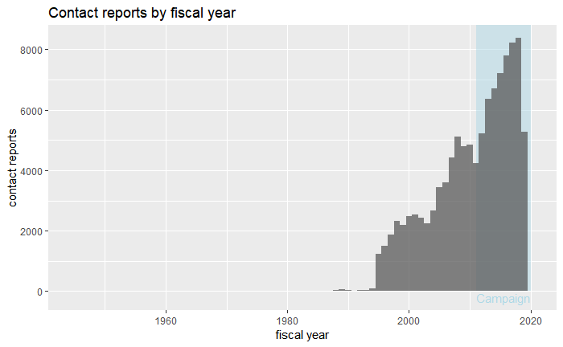

```r
visits %>%
  filter(CONTACT_FY > 1800) %>%
  ggplot(aes(x = CONTACT_FY)) +
  annotate('rect', xmin = 2011, xmax = 2020, ymin = 0, ymax = Inf, fill = 'lightblue', alpha = .5) +
  annotate('text', x = 2011, y = -200, label = 'Campaign', hjust = 0, color = 'lightblue') +
  geom_histogram(binwidth = 1, alpha = .75) +
  labs(title = 'Contact reports by fiscal year', x = 'fiscal year', y = 'contact reports')
```

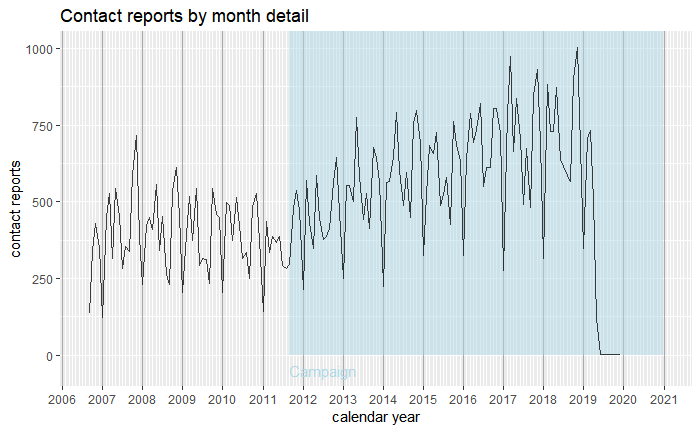

```r
visits %>%
  filter(CONTACT_FY >= 2007) %>%
  group_by(mo_yr = round_date(CONTACT_DATE, unit = 'month')) %>%
  summarise(n = length(ID_NUMBER)) %>%
  ggplot(aes(x = mo_yr, y = n)) +
  annotate('rect', xmin = ymd('20110901'), xmax = ymd('20201231')
           , ymin = 0, ymax = Inf, fill = 'lightblue', alpha = .5) +
  annotate('text', x = ymd('20110901'), y = -50, label = 'Campaign', hjust = 0, color = 'lightblue') +
  geom_line(alpha = .75) +
  labs(title = 'Contact reports by month detail', x = 'calendar year', y = 'contact reports') +
  scale_x_date(date_breaks = '1 year', date_labels = '%Y', date_minor_breaks = '1 month') +
  theme(panel.grid.major.x = element_line(color = 'darkgrey'))
```

```r
# Fiscal month function
fiscal_mo <- function(mo, start_mo = 9) {
  (mo - start_mo) %% 12 + 1
}
```

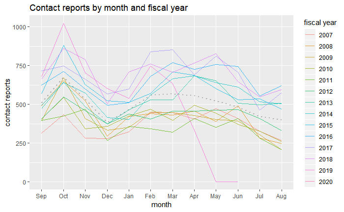

```r
vdat <- visits %>%
  filter(CONTACT_FY >= 2007) %>%
  group_by(mo = fiscal_mo(month(CONTACT_DATE)), CONTACT_FY) %>%
  summarise(n = length(ID_NUMBER))
vdat %>%
  ggplot(aes(x = mo, y = n)) +
  geom_line(aes(color = factor(CONTACT_FY), group = CONTACT_FY), alpha = .75) +
  geom_line(data = vdat %>% group_by(mo) %>% summarise(n = mean(n)), size = 1, alpha = .25, linetype = 'dotted') +
  labs(title = 'Contact reports by month and fiscal year', x = 'month', y = 'contact reports', color = 'fiscal year') +
  scale_x_continuous(breaks = 1:12, minor_breaks = NULL, labels = month.name[c(9:12, 1:8)] %>% str_sub(1, 3))
```

Historically, the count of contact reports has increased over time (almost certainly a combination of more outreach plus better data collection), and most activity has occurred in September through November and February through May

### Word counts

Word count distribution (log?)

```r
visits <- visits %>%
  mutate(
    # Count of words in SUMMARY
    words = str_count(SUMMARY, '\\w+')
    , source = 'summary'
    # If summary was invalid, count words in DESCRIPTION instead
    , text = ifelse(words >= 1, SUMMARY, DESCRIPTION)
    , source = ifelse(words >= 1, source, 'description') %>% factor()
    , words = ifelse(words >= 1, words, str_count(DESCRIPTION, '\\w+'))
  )
```

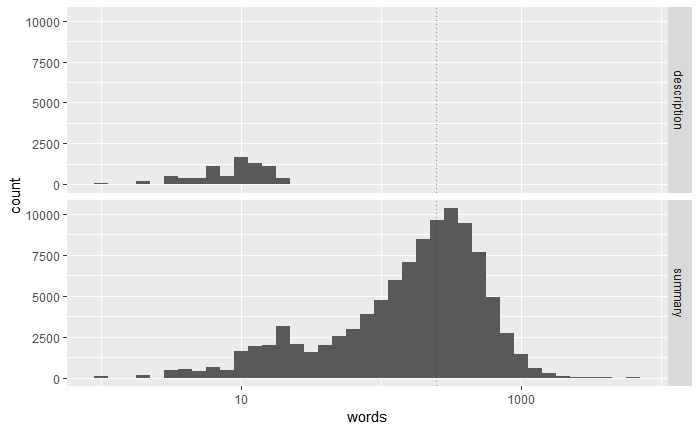

```r
visits %>%
  ggplot(aes(x = words)) +
  geom_histogram(binwidth = .1) +
  geom_vline(xintercept = mean(visits$words), color = 'blue', linetype = 'dotted', alpha = .5) +
  scale_x_log10() +
  facet_grid(source ~ .)
```

It turns out there are actually a number of observations that only have a description, with no valid visit summary filled in.

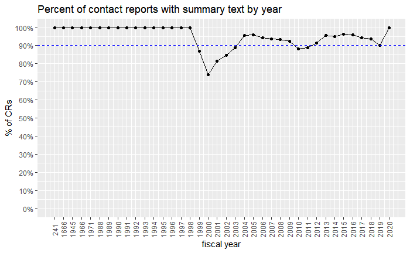

```r
vdat <- visits %>%
  group_by(CONTACT_FY, source) %>%
  summarise(n = length(ID_NUMBER)) %>%
  spread(source, n) %>%
  wranglR::ReplaceValues(old.val = NA, new.val = 0) %>%
  mutate(summary_pct = {summary / (description + summary)})
vdat %>%
  ggplot(aes(x = 1:nrow(vdat), y = summary_pct)) +
  geom_point() +
  geom_line() +
  geom_hline(yintercept = .9, color = 'blue', linetype = 'dashed') +
  scale_x_continuous(breaks = 1:nrow(vdat), labels = vdat$CONTACT_FY) +
  labs(title = 'Percent of contact reports with summary text by year'
       , x = 'fiscal year', y = '% of CRs') +
  scale_y_continuous(limits = c(0, 1), breaks = seq(0, 1, by = .1), labels = scales::percent) +
  theme(axis.text.x = element_text(angle = 90, vjust = .5))
```

I wonder what happened in FY 2000? There was a drop in entered summaries.

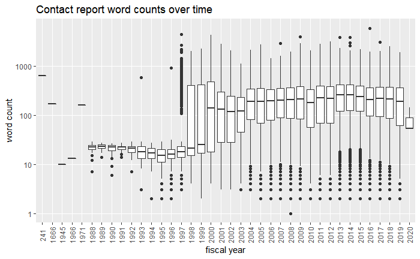

```r
# Word counts by year
visits %>%
  ggplot(aes(x = factor(CONTACT_FY), y = words + 1)) +
  geom_boxplot() +
  scale_y_log10(breaks = 10^(0:10), minor_breaks = NULL) +
  theme(axis.text.x = element_text(angle = 90, vjust = .5)) +
  labs(title = 'Contact report word counts over time'
       , y = 'word count', x = 'fiscal year')
```

Apparently 2000 was also the year people were asked to do more than paste the DESCRIPTION into the SUMMARY.

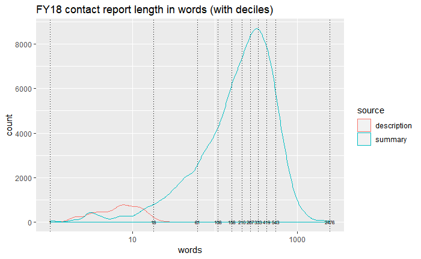

```r
vdat <- visits %>% filter(CONTACT_FY == 2018)
quants <- vdat %>% select(words) %>% unlist() %>%
  quantile(probs = seq(0, 1, by = .1))
vdat %>%
  ggplot(aes(x = words, color = source)) +
  geom_density(aes(y = ..count..)) +
  scale_x_log10() +
  geom_vline(xintercept = quants, linetype = 'dotted') +
  annotate(geom = 'text', x = quants, y = -.05, label = quants, size = 2) +
  labs(title = 'FY18 contact report length in words (with deciles)') +
  scale_y_continuous(breaks = seq(0, 1E4, by = 2E3))
```

Last year, the overwhelming majority of description-only contact reports were under 18 words. 10% of all contact reports still had fewer than 18 words. The median contact report had 210 words, which seems quite reasonable, and the middle 60% were 61 to 419 words. This suggests I’ll have a fair bit of text to work with.

## Merged data

Combine all text associated with a given entity into one large report.

```r
merged <- visits %>%
  # Drop any with a blank ID
  filter(trimws(ID_NUMBER) != '') %>%
  select(ID_NUMBER, text) %>%
  group_by(ID_NUMBER) %>%
  summarise_all(funs(paste(., collapse = ' '))) %>%
  mutate(
    words = str_count(text, '\\w+')
  )
```

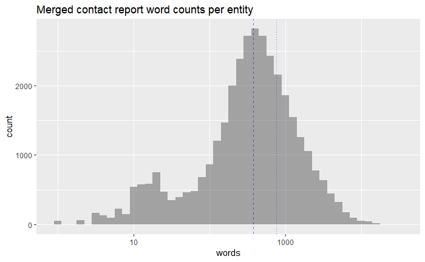

```r
merged %>%
  ggplot(aes(x = words)) +
  geom_histogram(binwidth = .1, alpha = .5) +
  geom_vline(xintercept = mean(merged$words), color = 'blue', linetype = 'dotted', alpha = .5) +
  geom_vline(xintercept = median(merged$words), color = 'blue', linetype = 'dashed', alpha = .5) +
  scale_x_log10() +
  labs(title = 'Merged contact report word counts per entity')
```

```r
summary(merged$words)
```

```
   Min. 1st Qu.  Median    Mean 3rd Qu.    Max.
    1.0   156.0   378.0   754.1   840.0 29128.0
```

Unsurprisingly this is quite a right-skewed distribution.

```r
quantile(merged$words, probs = seq(0, 1, by = .1))
```

```
     0%     10%     20%     30%     40%     50%     60%     70%     80%     90%    100%
    1.0    24.0   113.0   198.0   281.0   378.0   505.0   699.0  1035.0  1809.8 29128.0
```

It might make sense discarding the 10% of records with less than 24 words; this will look even worse after I experiment with stopword removal.

## Cleanup and stopwords

```r
# Helper functions for tm
# Replace punctuation with a space
# (http://stackoverflow.com/questions/25105702/how-to-give-space-between-2-words-after-removing-punctuation-and-numbers-text-mi)
replacePunctuation <- content_transformer(function(x) {gsub("[[:punct:]]", " ", x)})
# Replace arbitrary characters with a space
replaceAsSpace <- content_transformer(function(x, pattern) {gsub(pattern, " ", x)})
```

```r
corpus <- VCorpus(VectorSource(merged$text)) %>% # Read in the merged contact reports
  tm_map(content_transformer(tolower)) %>% # Lower case
  tm_map(removeNumbers) %>% # Strip numbers
  tm_map(replaceAsSpace, '(“|”|‘|’|`)') %>% # Remove assorted symbols
  tm_map(replacePunctuation) %>% # Strip punctuation
  tm_map(stripWhitespace) # Remove extra whitespace
```

```r
# Version without stopwords
corpus_ns <- corpus %>%
  tm_map(removeWords, stopwords('english')) %>% # Strip standard stopwords
  tm_map(stripWhitespace) # Remove extra whitespace
```

## Cleaned data exploration

```r
cleaned_docs <- wranglR::ListExtract(corpus, 'content') %>% data.frame()
cleaned_docs_ns <- wranglR::ListExtract(corpus_ns, 'content') %>% data.frame()
```

```r
cleaned_docs %>%
  mutate(words = str_count(content, '\\w+'))
```

[output not shown]